# 9 Visualization

true

# Visualization

Visualization is a key tool in empirical studies. The way we represent information can greatly help in conveying what we are trying to say, but also obfuscate it.

The field of data visualization is still relatively new. Notwithstanding, there are some general guidelines that can help you along the way (see, e.g., [Graphic Principles](https://github.com/GraphicsPrinciples/CheatSheet/blob/master/NVSCheatSheet.pdf)).

Four core tenants to keep in mind when visualizing data are:

- The “Why”: Identify the purpose of your visual device (e.g., to make a contrast between two groups clear; or to visualize how the data is distributed)
- The “What”: Identify the quantitative evidence to support the purpose
- The “Who”: Identify the intended audience and design your visualization to aid them
- The “Where”: Adapt design to presentation constraints

# Common types of visualizations

## Scatter plots

Particularly useful when data are continuous and there is a single relationship to depict

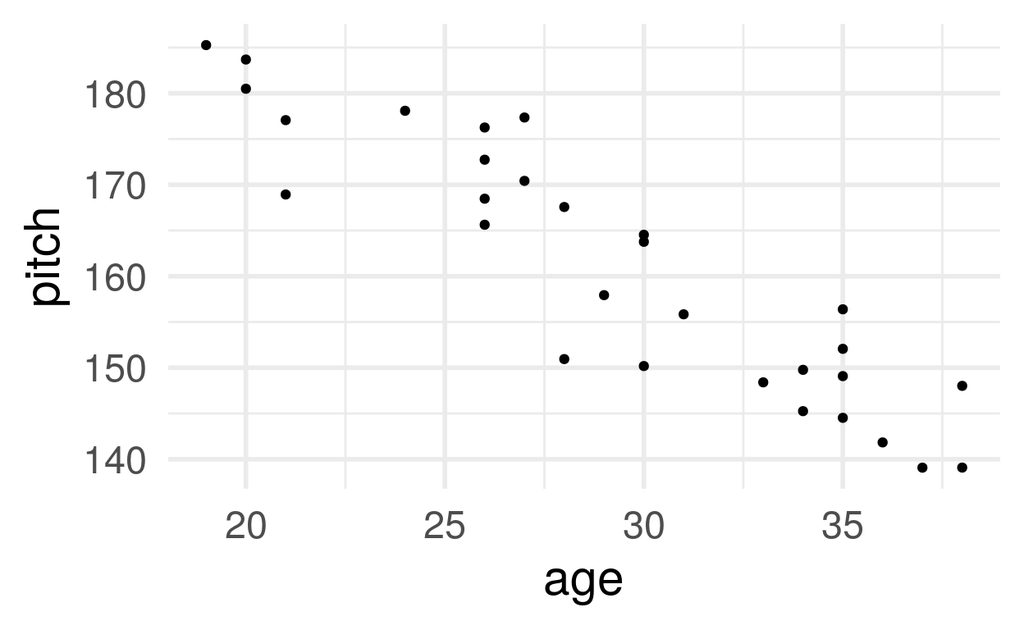

```r
ggplot(df, aes(x = age, y = pitch)) +
  geom_point() +
  theme_minimal(base_size = 22)
```

## Histograms

Particularly useful when you want to depict the distribution of a single variable

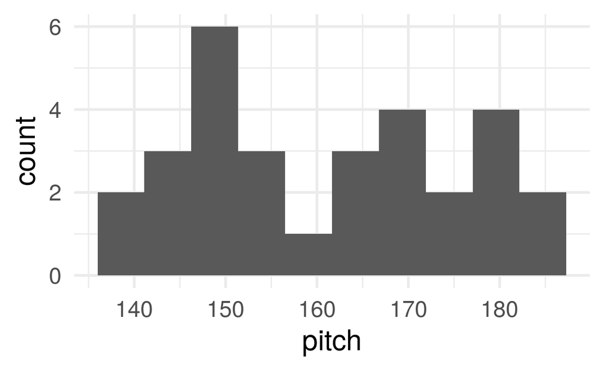

```r
ggplot(df, aes(x = pitch)) +
  geom_histogram(bins = 10) +
  theme_minimal(base_size = 22)
```

## Boxplots

Particularly useful when you want to depict the distribution of a single variable, often grouped

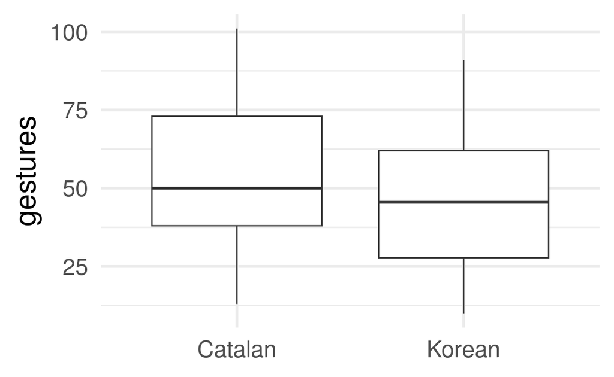

```r
df_gestures <- read.csv('https://tinyurl.com/gestures-data') #download data

ggplot(df_gestures, aes(x = language, y = gestures)) +
  geom_boxplot() +
  theme_minimal(base_size = 22) +
  theme(axis.title.x = element_blank())
```

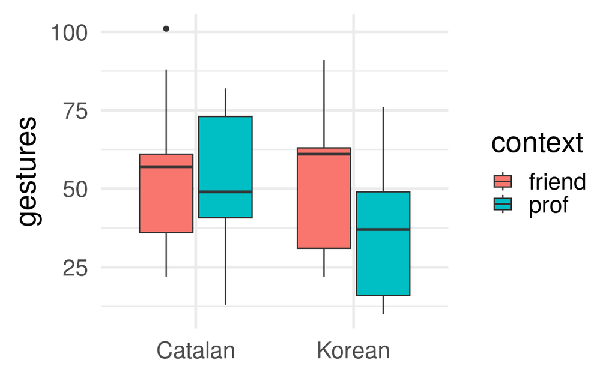

```r
df_gestures <- read.csv('https://tinyurl.com/gestures-data') #download data

ggplot(df_gestures, aes(x = language, y = gestures, fill = context)) +
  geom_boxplot() +
  theme_minimal(base_size = 22) +
  theme(axis.title.x = element_blank())
```

## Other types of visualizations

There are many more types of plots, and combinations thereof. You can, e.g., see a long array of possibilities here: https://r-statistics.co/Top50-Ggplot2-Visualizations-MasterList-R-Code.html

# ggplot2

`ggplot2` is a powerful package for plotting data. It is based on a theoretical analysis of data graphics: “The Grammar of Graphics” by Leland Wikinson.

## Components

Main ones:

- **data** what is plotted
- **mapping** how the data relates to what you see (“aesthetics”)
- **geom** what geometric object is used to draw each observation (points, lines, bars, etc)

Secondary ones:

- **stat**: optional transformations of the data
- **facet**: split data into multiple panels by criterion

## Example 1

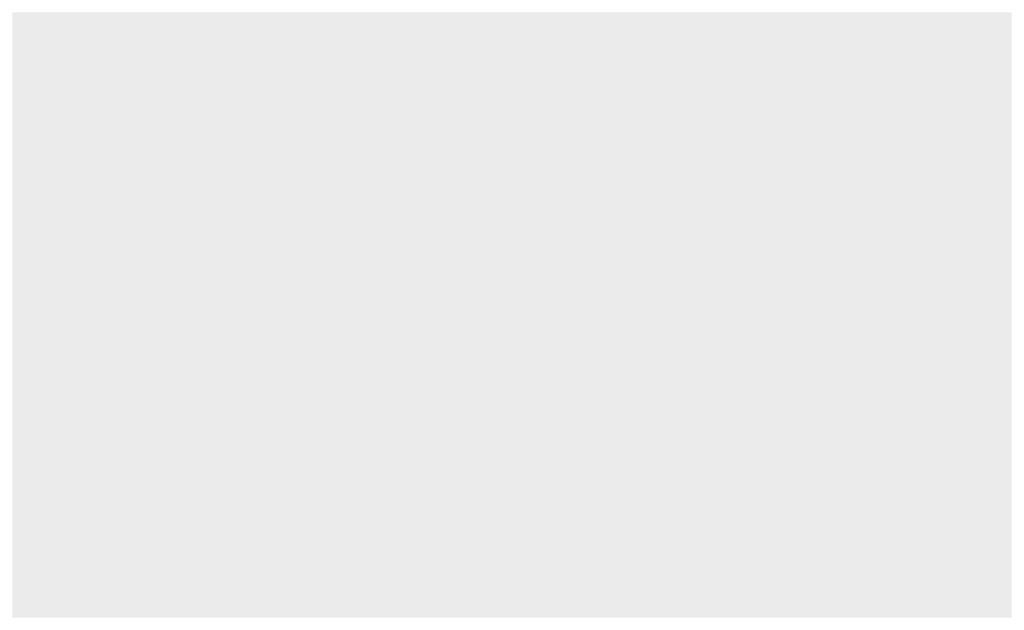

```r
ggplot(data = df) #just specifies where data comes from
```

```r
                  #but doesn't say what to draw nor how to draw it
```

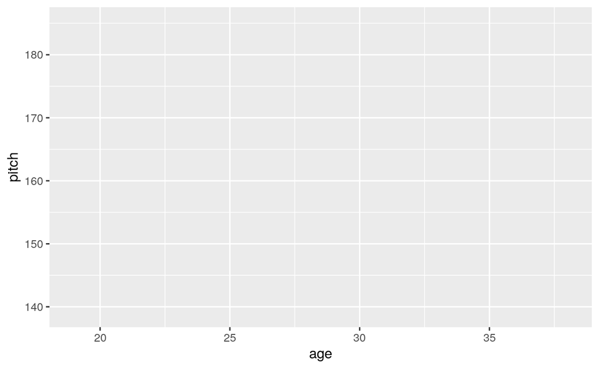

```r
ggplot(data = df, aes(x = age, y = pitch)) #says what to draw
```

```r
                                           #but not how
```

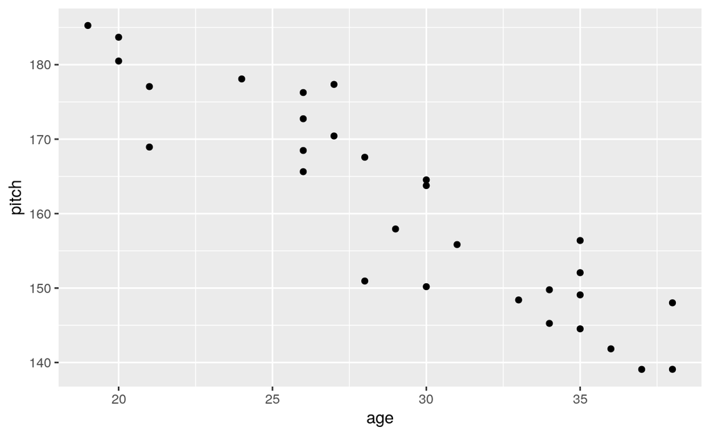

```r
ggplot(data = df, aes(x = age, y = pitch)) + #what to draw
  geom_point()                               #how to draw it
```

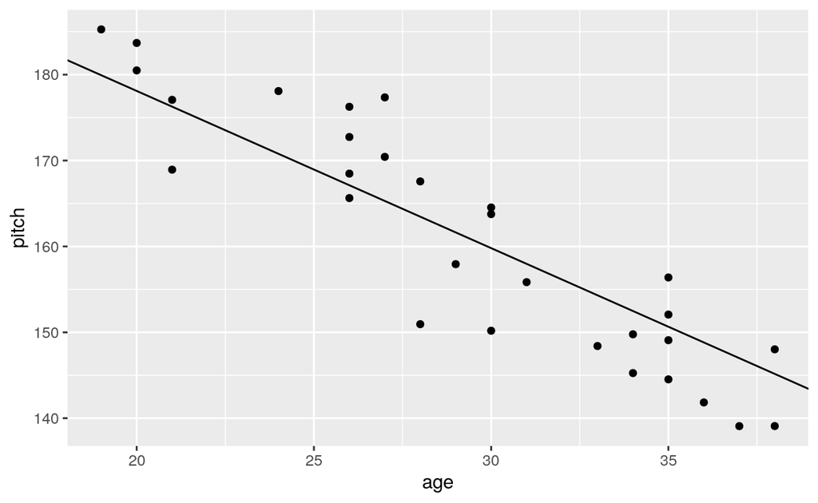

```r
ggplot(data = df, aes(x = age, y = pitch)) +    #what to draw
  geom_point()                             +    #how to draw it
  geom_abline(intercept = 214.7, slope = -1.83) #add a line
```

## Example 2

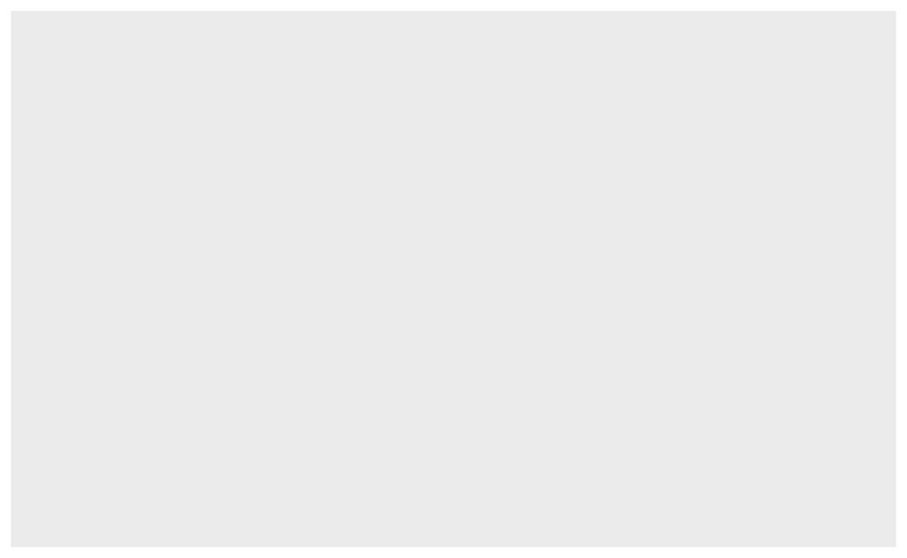

```r
ggplot(data = df_gestures) #just specifies where data comes from
```

```r
                  #but doesn't say what to draw nor how to draw it
```

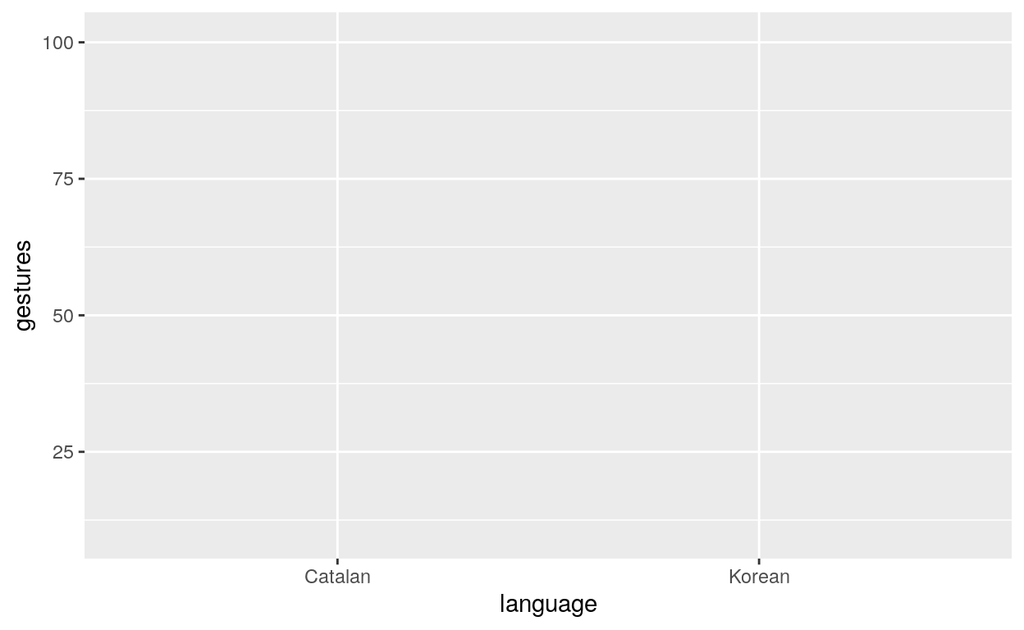

```r
ggplot(data = df_gestures, aes(x = language, y = gestures)) #says what to draw
```

```r
                                           #but not how
```

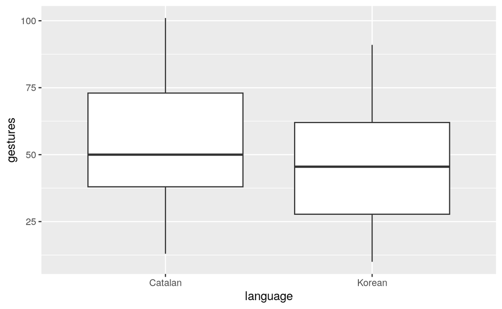

```r
ggplot(data = df_gestures, aes(x = language, y = gestures)) +
  geom_boxplot()
```

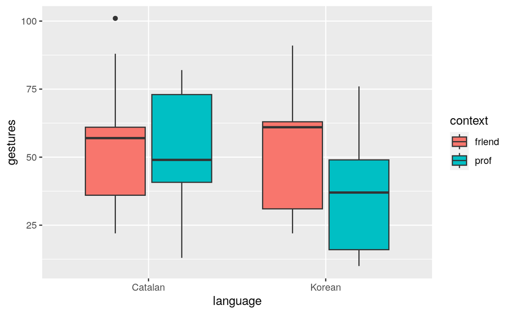

```r
ggplot(data = df_gestures, aes(x = language, y = gestures, fill = context)) +
  geom_boxplot()
```

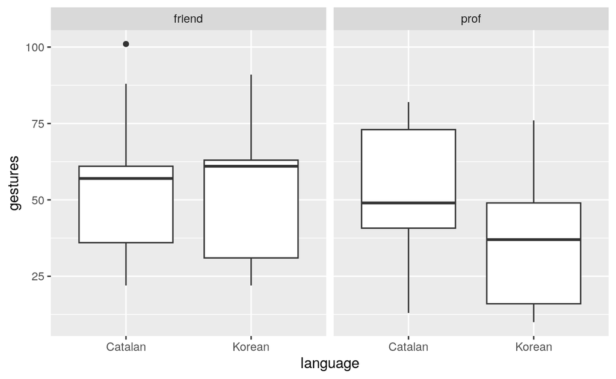

```r
ggplot(data = df_gestures, aes(x = language, y = gestures)) +
  geom_boxplot() +
  facet_wrap( ~ context) #split into panels
```

## Beautification

Let’s make these plots a bit prettier

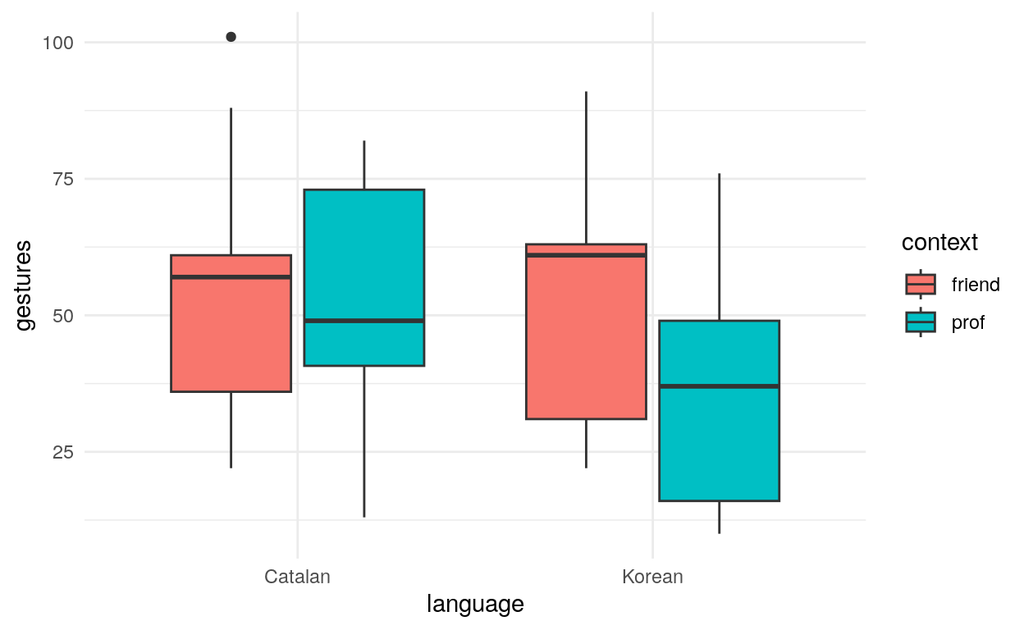

```r
ggplot(data = df_gestures, aes(x = language, y = gestures, fill = context)) +
  geom_boxplot() +
  theme_minimal() #change overall appeareance of the plot
```

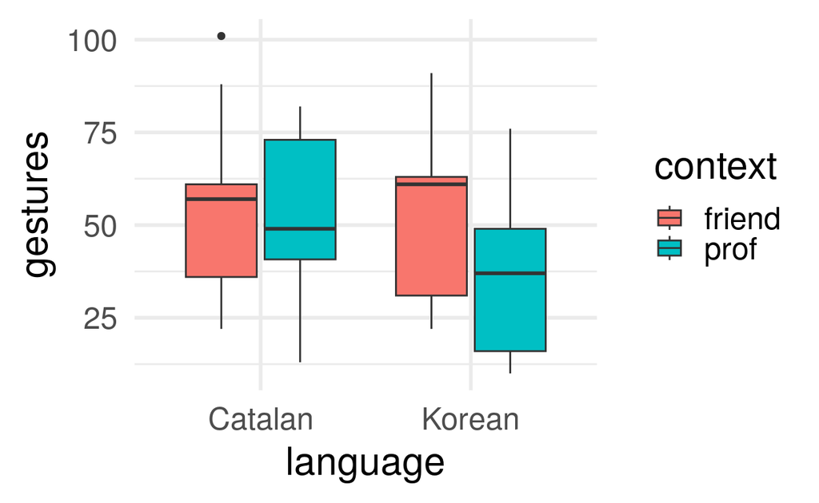

```r
ggplot(data = df_gestures, aes(x = language, y = gestures, fill = context)) +
  geom_boxplot() +
  theme_minimal(base_size = 22) #change theme and make labels bigger
```

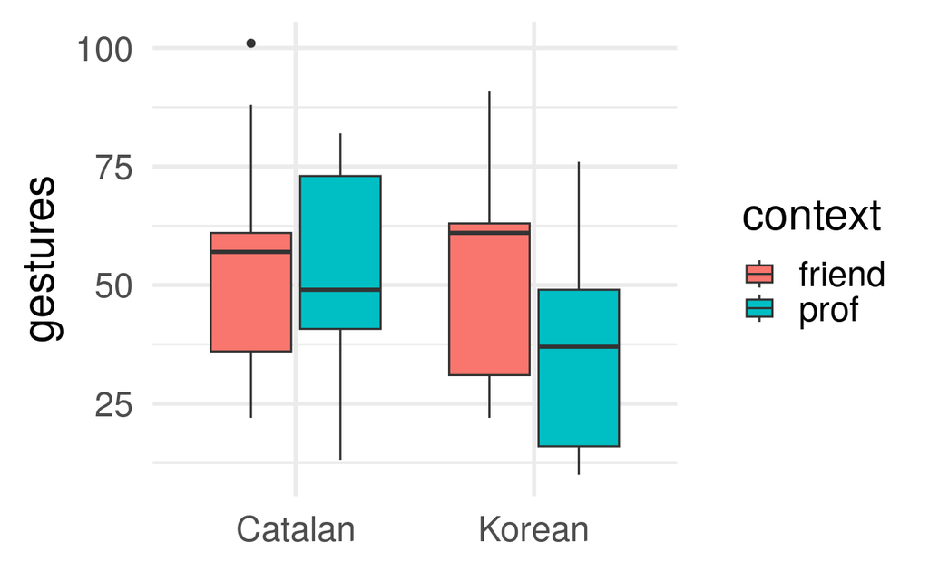

```r
ggplot(data = df_gestures, aes(x = language, y = gestures, fill = context)) +
  geom_boxplot() +
  theme_minimal(base_size = 22) + #change theme and make labels bigger
  theme(axis.title.x = element_blank()) #remove reddundant information
```

# Further reading/watching

Partially citing from [ggplot’s documentation](https://ggplot2.tidyverse.org/):

1. The [Data Visualisation](https://r4ds.had.co.nz/data-visualisation.html) and [Graphics for communication](https://r4ds.had.co.nz/graphics-for-communication.html) chapters in R for Data Science. R for Data Science is designed to give you a comprehensive introduction to the tidyverse, and these two chapters will get you up to speed with the essentials of ggplot2 as quickly as possible.
2. If you’d like to follow a webinar, try [Plotting Anything with ggplot2 by Thomas Lin Pedersen](https://r-graphics.org/).
3. If you want to dive into making common graphics as quickly as possible, [look at] [The R Graphics Cookbook by Winston Chang](https://r-graphics.org/). It provides a set of recipes to solve common graphics problems.

Beyond `ggplot2`:

- [Graphics principles](https://graphicsprinciples.github.io/)
- [Franconeri et al (2021): The Science of Visual Data Communication: What Works](https://www2.econ.iastate.edu/tesfatsi/ScienceOfVisualDataCommunication.FranconeriEtAl2021.pdf)

## Corrections

If you spot a mistake or have suggestions, please get in touch with [Thomas Brochhagen](https://brochhagen.github.io) or [create an issue](https://github.com/metodesempirics/metodesempirics.github.io/issues/new)